# "Enough Docker to be Dangerous"

Joyce Cahoon  
November 10, 2017

### Install Docker

First things first, install: https://docs.docker.com/engine/installation/

Then create a docker hub login: https://hub.docker.com

### What is Docker?

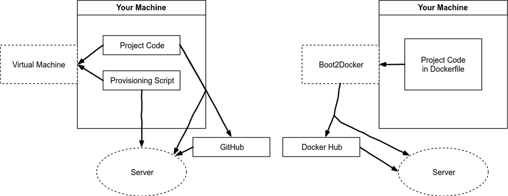

### Basic Docker Fun

```c
docker run <image>

docker start <name|id>

docker stop <name|id>

docker ps [-a include stopped containers]

docker rm <name|id>
```

### Let's Try It

```c
docker

docker login

docker run tutum/hello-world
```

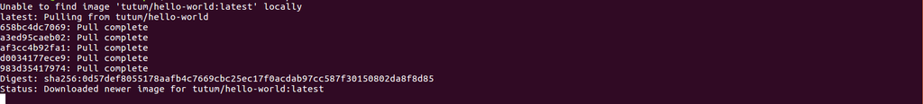

In another terminal, run:

```c
docker ps
```

### Accessing Your Container

```c
docker run -p 8080:80 tutum/hello-world
```

Check it out on your browser, go to http://localhost:8080/

[figure not shown]

### Clean Up

```c
docker ps -a

docker rm <name|id>

docker ps -a
```

### Let's Get Fancy

```c
docker run -d --name web1 -p 8080:80 tutum/hello-world

docker run -d --name web2 -p 8082:80 tutum/hello-world

docker run -d --name web3 -p 8083:80 tutum/hello-world

docker stop web1

docker ps -a

docker start web1
```

### Docker and R

```c
docker run --rm -p 8787:8787 rocker/verse
```

Check out http://localhost:8787/. You should be able to sign-in with:

- Username: rstudio
- Password: rstudio

Now you can use Rstudio in your browser the same way you would on your desktop.

### Enabling Reproducibility

```c
docker run --rm -p 8787:8787 -v ~/r-docker-tutorial:/home/rstudio/r-docker-tutorial rocker/verse
```

Use the \( \texttt{-v} \) flag to access data on your local hard drive as well as save things there.

Make sure paths placed to the left of \( \texttt{:} \) is a path on your machine.

### Example: Simulations in purrr

Use functions in \( \texttt{purrr} \) to perform iterative tasks:

> for each ___ do ____

There is nothing new here, you might already be addressing this in your code with

- copy & paste
- for loops
- \( \texttt{apply} \)

### Example: Simulation in purrr

How I used to run simulations…

```r
nreps <- 10000
n <- 5
results <- matrix(NA, nrow = nreps, ncol = 2)
for(i in 1:nreps){
  one_rep <- rnorm(n = 5, mean = 0, sd = 1)
  results[i, 1] <- sqrt(mean(one_rep^2))
  results[i, 2] <- median(abs(one_rep-median(one_rep)))
}
```

### Example: Simulation in purrr

How I used to run simulations…

Let's do this for varying \( \texttt{n} \) and \( \texttt{sd} \):

```r
nreps <- 10000
combinations <- expand.grid(n = c(5, 10, 15), sd = c(1, 2, 3))
results <- combinations[rep(seq_len(nrow(combinations)), each = nreps),]
system.time(
  for(i in 1:dim(results)[1]){
    one_rep <- rnorm(n = results$n[i], mean = 0, sd = results$sd[i])
    results$rms[i] <- sqrt(mean(one_rep^2))
    results$mad[i] <- median(abs(one_rep-median(one_rep)))
  }
)
```

### Example: Simulation in purrr

Maybe this is what we should do…

```r
nreps <- 10000
simulator <- function(n, sd){
  one_rep <- rnorm(n = n, mean = 0, sd = sd)
  rms <- sqrt(mean(one_rep^2))
  mad <- median(abs(one_rep-median(one_rep)))
  return(list(one_rep = one_rep,
              rms = rms,
              mad = mad))
}
combinations <- expand.grid(n = c(5, 10, 15), sd = c(1, 2, 3))
results <- combinations[rep(seq_len(nrow(combinations)), each = nreps),]
system.time(
  results <- apply(results, 1, function(x) simulator(x[1], x[2]))
)
# Now you have to unlist everything....
head(results)
```

### Example: Simulation in purrr

Life could be so much easier…

```r
library(purrr)
library(dplyr)
library(reshape)
library(ggplot2)

simulator <- function(n, sd){ rnorm(n = n, mean = 0, sd = sd)}
combinations <- expand.grid(n = c(5, 10, 15), sd = c(1, 2, 3))
results <- combinations[rep(seq_len(nrow(combinations)), each = nreps),]
system.time(output <- results %>%
    mutate(sim = map2(n, sd, simulator),
           rms = map_dbl(sim, ~sqrt(mean(.^2))),
           mad = map_dbl(sim, ~median(abs(.)))))

# Let's visualize the results ---------------------------------------------
output_melted <- melt(select(output, -sim), id.vars=c("n", "sd"))
ggplot(output_melted, aes(x = n, y = value, col = variable)) +
  geom_boxplot() +
  facet_wrap(~sd)
ggsave("picture.pdf")
```

[output not shown]

### Saving Your Current Instance

```c
docker ps

docker commit -m "[INSERT COMMENT]" [CONTAINER ID] [IMAGE NAME]

docker images
```

### Getting Image Up To Docker Hub

```c
docker login --username=yourhubusername --email=youremail@ncsu.edu

docker images
```

If all your files and data are where they need to be, then:

```c
docker tag [IMAGE ID] your_docker_hub_username/[IMAGE NAME]:[ANY TAG]

docker push your_docker_hub_username/[IMAGE NAME]
```

### Run it on another machine

You can find public images here: https://hub.docker.com/

```c
docker run jyu21/slg_purr_example:v1

docker ps

docker exec -it [CONTAINER ID] bash

Rscript [YOUR SCRIPT].R
```

[figure not shown]

ROpenSci's [Launching Docker](http://ropenscilabs.github.io/r-docker-tutorial/02-Launching-Docker.html)  
Draw.io's [Making Diagrams](https://www.draw.io/)  
Sean Kross' [Enough Docker To Be Dangerous](http://seankross.com/2017/09/17/Enough-Docker-to-be-Dangerous.html?utm_content=bufferbdfbf&utm_medium=social&utm_source=twitter.com&utm_campaign=buffer)  
Mine Cetinkaya-Rundel's [Purrr](http://rpubs.com/minebocek/rladies-rtp-purrr)  
Dr. Post, Kara & Todd for [SLG](http://www4.stat.ncsu.edu/%7Epost/slg)